# Random Chance

### How do you know your ML results aren’t due to chance?

In hypothesis testing, scientists use p-values to make sure their observations are not due to chance. Can we do something similar in ML?

I used the titanic dataset on kaggle to explore this idea.

### The first step is to get the training set and get it ready for modeling.

```r
#Get Train Set Ready *******
Boat <- read.csv("train.csv")

#Title and Last Name
Boat$title<- word(Boat$Name,1, sep = fixed('.'))
Boat$title<- word(Boat$title,-1)
Boat$lastName <- word(Boat$Name, 1)

##Embarked
Boat$Embarked[Boat$Embarked == ""] <- "C"

##Remove
Boat$Ticket <- NULL
Boat$lastName <- NULL
TrainID <- Boat$PassengerId
Boat$PassengerId <- NULL
Boat$Name <- NULL

##Factors
Boat$Sex <- as.numeric(Boat$Sex)
Boat$Pclass <- as.factor(as.numeric(Boat$Pclass))

##Age
Boat$Age[is.na(Boat$Age)] <- median(Boat$Age, na.rm = TRUE)
Boat$Fare[is.na(Boat$Fare)] <- median(Boat$Fare, na.rm = TRUE)

##Title
Boat$title2[Boat$title == "Lady" |
              Boat$title == "Countess" |
              Boat$title == "Don" |
              Boat$title == "Dr" |
              Boat$title == "Rev" |
              Boat$title == "Sir" |
              Boat$title == "Johnkheer"] <- "Rare"

Boat$title2[Boat$title == "Major" |
               Boat$title == "Countess" |
               Boat$title == "Capt"] <- "Officer"


Boat$title2[is.na(Boat$title2)] <- "Common"
Boat$title2 <- NULL
Boat$Cabin <- NULL
#write.csv(Boat, file = "trainboat_fin.csv")
```

### The second step is to do the same for the testing dataset.

```r
boattest <- read.csv("test.csv")

##Title and Last Name
boattest$title<- word(boattest$Name,1, sep = fixed('.'))
boattest$title<- word(boattest$title,-1)
boattest$lastName <- word(boattest$Name, 1)

##Embarked
boattest$Embarked[is.na(boattest$Embarked)] <- "C"

##Remove
boattest$Ticket <- NULL
boattest$lastName <- NULL
TestID <- boattest$PassengerId
boattest$PassengerId <- NULL
boattest$Name <- NULL

##Factor
boattest$title <- as.factor(boattest$title)
boattest$Sex <- as.numeric(boattest$Sex)
boattest$Pclass <- as.factor(as.numeric(boattest$Pclass))


##Age
boattest$Age[is.na(boattest$Age)] <- median(boattest$Age, na.rm = TRUE)
boattest$Fare[is.na(boattest$Fare)] <- median(boattest$Fare, na.rm = TRUE)

##Title
boattest$title2[boattest$title == "Lady" |
                   boattest$title == "Countess" |
                   boattest$title == "Don" |
                   boattest$title == "Dr" |
                   boattest$title == "Rev" |
                   boattest$title == "Sir" |
                   boattest$title == "Johnkheer"] <- "Rare"

boattest$title2[boattest$title == "Major" |
               boattest$title == "Countess" |
               boattest$title == "Capt"] <- "Officer"


boattest$title2[is.na(boattest$title2)] <- "Common"


boattest <- as.data.frame((boattest))

boattest$title <- as.character(boattest$title)
boattest$title[boattest$title == "Dona"] <- 'Don'
boattest$title <- as.factor(boattest$title)
boattest$title2 <- NULL
boattest$Cabin <- NULL

#write.csv(boattest, file = "boattest_fin.csv")
```

### I ran an xbgTree algorithm on the training data.

```r
#Rmodel*****************
library(caret)
library(e1071)
library(MLmetrics)
set.seed(1)

xbg <- train(factor(Survived) ~.,
             method = 'xgbTree',
             data = Boat); print(xbg)
```

```
## eXtreme Gradient Boosting
##
## 891 samples
##   8 predictor
##   2 classes: '0', '1'
##
## No pre-processing
## Resampling: Bootstrapped (25 reps)
## Summary of sample sizes: 891, 891, 891, 891, 891, 891, ...
## Resampling results across tuning parameters:
##
##   eta  max_depth  colsample_bytree  subsample  nrounds  Accuracy
##   0.3  1          0.6               0.50        50      0.8121161
##   0.3  1          0.6               0.50       100      0.8133565
##   0.3  1          0.6               0.50       150      0.8118397
##   0.3  1          0.6               0.75        50      0.8162939
##   0.3  1          0.6               0.75       100      0.8125532
##   0.3  1          0.6               0.75       150      0.8151351
##   0.3  1          0.6               1.00        50      0.8144614
##   0.3  1          0.6               1.00       100      0.8172839
##   0.3  1          0.6               1.00       150      0.8141495
##   0.3  1          0.8               0.50        50      0.8112863
##   0.3  1          0.8               0.50       100      0.8125619
##   0.3  1          0.8               0.50       150      0.8130633
##   0.3  1          0.8               0.75        50      0.8131313
##   0.3  1          0.8               0.75       100      0.8146212
##   0.3  1          0.8               0.75       150      0.8139228
##   0.3  1          0.8               1.00        50      0.8137571
##   0.3  1          0.8               1.00       100      0.8154954
##   0.3  1          0.8               1.00       150      0.8154808
##   0.3  2          0.6               0.50        50      0.8219314
##   0.3  2          0.6               0.50       100      0.8233745
##   0.3  2          0.6               0.50       150      0.8228786
##   0.3  2          0.6               0.75        50      0.8239694
##   0.3  2          0.6               0.75       100      0.8281833
##   0.3  2          0.6               0.75       150      0.8238817
##   0.3  2          0.6               1.00        50      0.8212078
##   0.3  2          0.6               1.00       100      0.8232374
##   0.3  2          0.6               1.00       150      0.8237678
##   0.3  2          0.8               0.50        50      0.8211022
```

[output cut: 182 more lines]

```
##   0.5875026
##   0.6217011
##   0.6112793
##   0.5976075
##   0.6191756
##   0.6144657
##   0.6086937
##
## Tuning parameter 'gamma' was held constant at a value of 0
##
## Tuning parameter 'min_child_weight' was held constant at a value of 1
## Accuracy was used to select the optimal model using the largest value.
## The final values used for the model were nrounds = 100, max_depth = 2,
##  eta = 0.3, gamma = 0, colsample_bytree = 0.6, min_child_weight = 1
##  and subsample = 0.75.
```

```r
confusionMatrix(xbg)
```

```
## Bootstrapped (25 reps) Confusion Matrix
##
## (entries are percentual average cell counts across resamples)
##
##           Reference
## Prediction    0    1
##          0 54.8 10.1
##          1  7.1 28.0
##
##  Accuracy (average) : 0.828
```

### This is where it get’s interesting…

So I have a basic model that I ran on a famous dataset, now what?

If you want to compare your training results to chance, then one way to do it is to randomized your dataset and rerun it through the algorithm.

```r
##Perturb Data *****
Boat_random <- Boat
Boat_Label <- Boat$Survived
Boat_random$Survived <- NULL
Boat_random = as.data.frame(lapply(Boat_random, function(x) { sample(x) }))
```

### The next step is to take the random data that I created and use my model to make predictions.

```r
random_pred <-predict(xbg, Boat_random, type="prob")
```

### After that, I wanted to see how well the model predicted when there was no pattern in the data in comparison to the actual values.

The model shouldn’t predict well because there are no real relationships in the data. However, it should get some right just by chance. The way I did this was I subtracted the predicted probability by the actual value (0 or 1) and then took the average of the absolute difference)

```r
Boat_random$Actual <- Boat_Label
Boat_random$Random_Pred <- random_pred[,2]

Boat_random$Actual <- Boat_Label
Boat_random$Survived[Boat_random$Actual == 1] <- "Yes"
Boat_random$Survived[Boat_random$Actual == 0] <- "No"

Boat_random$diff <- Boat_random$Actual - Boat_random$Random_Pred
Boat_random$diff_abs <- abs(Boat_random$diff)
mean(Boat_random$diff_abs)
```

```
## [1] 0.4804751
```

### Even with random data the model is, on average, wrong 48% of the time and correct 52% of the time.

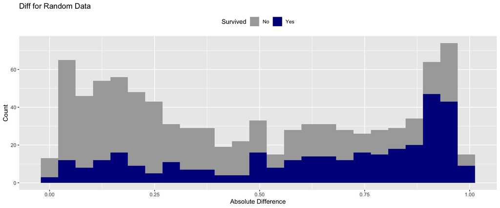

### Finally, I wanted to see what the this metric would look like for the real trainig data.

##With meaningful data the modeling was incorrect only 20% of the time, which is a big improvement than the prior difference score.

```r
#Predict on training data for comparison**********
boat_training_exp <- Boat
survived <- boat_training_exp$Survived
boat_training_exp$Survived <- NULL

real_pred <-predict(xbg, boat_training_exp,type="prob")

boat_training_exp$prediction <- real_pred[,2]
boat_training_exp$actual <- survived

boat_training_exp$diff <- boat_training_exp$actual - boat_training_exp$prediction

boat_training_exp$diff_abs <- abs(boat_training_exp$diff)
mean(boat_training_exp$diff_abs)
```

```
## [1] 0.2052488
```

[figure not shown]

```r
boat_training_exp$Survived[boat_training_exp$actual == 1] <- "Yes"
boat_training_exp$Survived[boat_training_exp$actual == 0] <- "No"
```